# Assignment 1 in interpretable machine learning

We are tasked with building a predictive regression model, with the best possible prediction. This submission will be split up into several parts:

- Initial data preprocessing and overview
- Introduction into the mathematics
- Modelling and justification
- Comparative discussion

## Initial data preprocessing and overview

The given data has the form:

```
##  [1] "ID"                   "Date_start_contract"  "Date_last_renewal"
##  [4] "Date_next_renewal"    "Date_birth"           "Date_driving_licence"
##  [7] "Distribution_channel" "Seniority"            "Policies_in_force"
## [10] "Max_policies"         "Max_products"         "Lapse"
## [13] "Date_lapse"           "Payment"              "Premium"
## [16] "Cost_claims_year"     "N_claims_year"        "N_claims_history"
## [19] "R_Claims_history"     "Type_risk"            "Area"
## [22] "Second_driver"        "Year_matriculation"   "Power"
## [25] "Cylinder_capacity"    "Value_vehicle"        "N_doors"
## [28] "Type_fuel"            "Length"               "Weight"
```

We are asked to predict the **Cost_claims_year** given the rest of the covariate-vector. Initially it is important to note that out data is a classical insurance dataset, where we are given rows corresponding to insurance periode for a given contract. There are several issues with this, since some contracts might overlap into multiple contracts, which can be identified by the ID. It is however very difficult to locate these policies, and we overlook this issue.

There are numerous char. vectors in the data, which can be seen here:

```
## Classes 'data.table' and 'data.frame':   105555 obs. of  30 variables:
##  $ ID                  : int  1 1 1 1 2 2 3 3 3 3 ...
##  $ Date_start_contract : chr  "05/11/2015" "05/11/2015" "05/11/2015" "05/11/2015" ...
##  $ Date_last_renewal   : chr  "05/11/2015" "05/11/2016" "05/11/2017" "05/11/2018" ...
##  $ Date_next_renewal   : chr  "05/11/2016" "05/11/2017" "05/11/2018" "05/11/2019" ...
##  $ Date_birth          : chr  "15/04/1956" "15/04/1956" "15/04/1956" "15/04/1956" ...
##  $ Date_driving_licence: chr  "20/03/1976" "20/03/1976" "20/03/1976" "20/03/1976" ...
##  $ Distribution_channel: chr  "0" "0" "0" "0" ...
##  $ Seniority           : int  4 4 4 4 4 4 15 15 15 15 ...
##  $ Policies_in_force   : int  1 1 2 2 2 2 1 1 1 1 ...
##  $ Max_policies        : int  2 2 2 2 2 2 2 2 2 2 ...
##  $ Max_products        : int  1 1 1 1 1 1 1 1 1 1 ...
##  $ Lapse               : int  0 0 0 0 0 0 0 0 0 0 ...
##  $ Date_lapse          : chr  "" "" "" "" ...
##  $ Payment             : int  0 0 0 0 1 1 0 0 0 0 ...
```

[output cut: 18 more lines]

One could, model some of the char. vectors like proposed in the lectures, by
$$\begin{align*}
X_i &= E(Y \mid X_i ) \\
&=\int_Y y\ \mu(x, dy)
\end{align*}$$
where $\mu$ is the appropriate probability kernel, and we let $y$ be our response. However, we choose to take the our char. vectors and round them to yearly values, which then has a ordinal ordering and can thus be used as features. Further we take and one-hot encode *Distribution_channel* by creating three new features which are either $1$ or $0$. Same for the type of fuel.

Next there are some missing values.

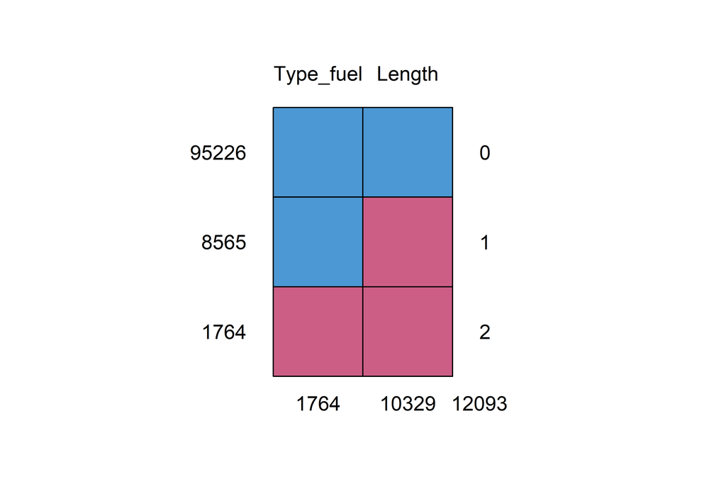

Missing data plot, right axis shows numer of missing columns in that row, and the left axis show how many rows have this missingness pattern

```
##       Type_fuel Length
## 95226         1      1     0
## 8565          1      0     1
## 1764          0      0     2
##            1764  10329 12093
```

Finally we look at the correlation between the covariates.

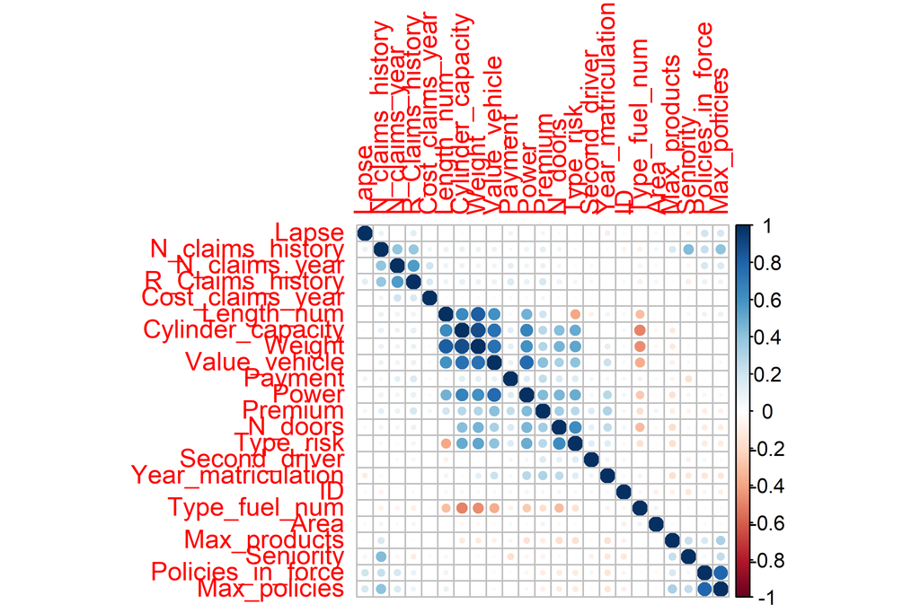

Correlation plot between the continious covariates

We notice some clusters, most meaningfull between *Cylinder_capacity*, *Value_vehicle* and *Weight* which is expected. We deem these to have significant predictive ability, and thus we choose to not remove these. The top left cluster, will be ignored for now, since we will later introduce a data-transformation which affects this cluster in a high degree.

##### Data Aggregation

For our data aggregation we want to have the ability to assume independence, which we have if we aggregate the rows into being one policy. There are several problems to tacle to achive data in the desired format. We have to both choose an appropriate aggreations function, and we have to consider events where the insured object change. We start off by identifying some unique-identifiers. If theme columns change, we deem the contract to insure a new car, or at least insure something that is independent of what was previously insured. Amongst these unique identifiers are Length, Weight, Power etc. so things which change, probably mean that the thing that is insured has changes. \ Next, we look at how we have aggregated data.

So we have $Z_i(\omega_i) := (X_i(\omega_i), Y_i(\omega_i)): (\Omega_i, \mathcal{F}_i) \rightarrow ( \mathcal{X} \times \mathcal{Y}, \mathcal{B}(\mathcal{X} \times \mathcal{Y}))$, where by aggregating data row-wise we obtain
$$\begin{align*}
P\bigl(Z_i \in A,\; Z_k \in B\bigr)
&= P\bigl(Z_i \in A\bigr)\,P\bigl(Z_k \in B\bigr),
\quad A, B \in \mathcal{B}(\mathcal{X}\times\mathcal{Y}).
\end{align*}$$

However this is an empirical assumption which can be violated by catastrophe events.

The aggregating is done by formatting the date covariates such that we can calculate the contract exposure, where we note that one year means $E = 1$, and then sum over the entire *ID*. Futher we take the premium, for the second to last entry, since we dont want to have forward-leakage in our data. The same is done for *cost_claims_history*, and related rows. We apply a mix of sum and max functions on the remaining rows to ensure that we aggregate data.